# Gender and social media use

Dipankar Lahiri

2025-02-27

This is an analysis of a random sample dataframe of 2189 individuals classified on Gender into Male and Female. Their responses on use of Facebook and Twitter respectively were entered as binary nominal variables.

# Main findings

```r
my_df %>% count(Gender) %>% mutate(percentage = n / sum(n) * 100)
```

```
## # A tibble: 2 × 3
##   Gender     n percentage
##   <chr>  <int>      <dbl>
## 1 Female  1189       54.3
## 2 Male    1000       45.7
```

```r
my_df %>% count(Use_Facebook) %>% mutate(percentage = n / sum(n) * 100)
```

```
## # A tibble: 2 × 3
##   Use_Facebook     n percentage
##   <chr>        <int>      <dbl>
## 1 No             938       42.9
## 2 Yes           1251       57.1
```

```r
my_df %>% count(Use_Twitter) %>% mutate(percentage = n / sum(n) * 100)
```

```
## # A tibble: 2 × 3
##   Use_Twitter     n percentage
##   <chr>       <int>      <dbl>
## 1 No           1823       83.3
## 2 Yes           366       16.7
```

Summary of variable counts: The sample had 1000 males (46%) and 1189 females (54%). The sample had 1251 Facebook users and 938 non-users, or 57% of the sample were Facebook users. The sample had 366 Twitter users and 1823 non-users, or 17% of the sample were Twitter users.

**Hypotheses: There is an association between gender and social media use.**

### Gender and Facebook Use

```r
chisq.test(
  x = my_df$Gender,
  y = my_df$Use_Facebook
)
```

```
##
##  Pearson's Chi-squared test with Yates' continuity correction
##
## data:  my_df$Gender and my_df$Use_Facebook
## X-squared = 18.046, df = 1, p-value = 0.00002156
```

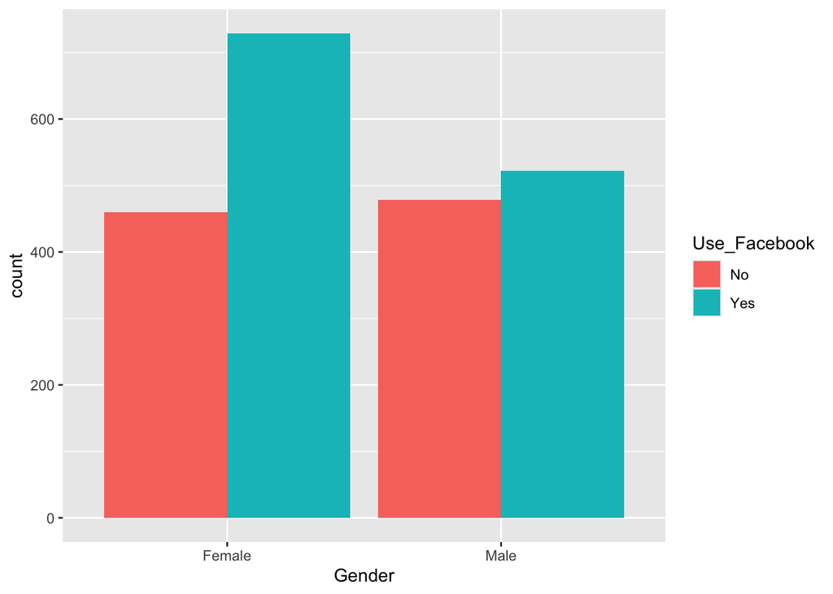

```r
my_df %>%
  ggplot (aes(x=Gender, fill = Use_Facebook)) + geom_bar (position = 'dodge')
```

### Gender and Twitter Use

```r
chisq.test(
  x = my_df$Gender,
  y = my_df$Use_Twitter
)
```

```
##
##  Pearson's Chi-squared test with Yates' continuity correction
##
## data:  my_df$Gender and my_df$Use_Twitter
## X-squared = 0.70466, df = 1, p-value = 0.4012
```

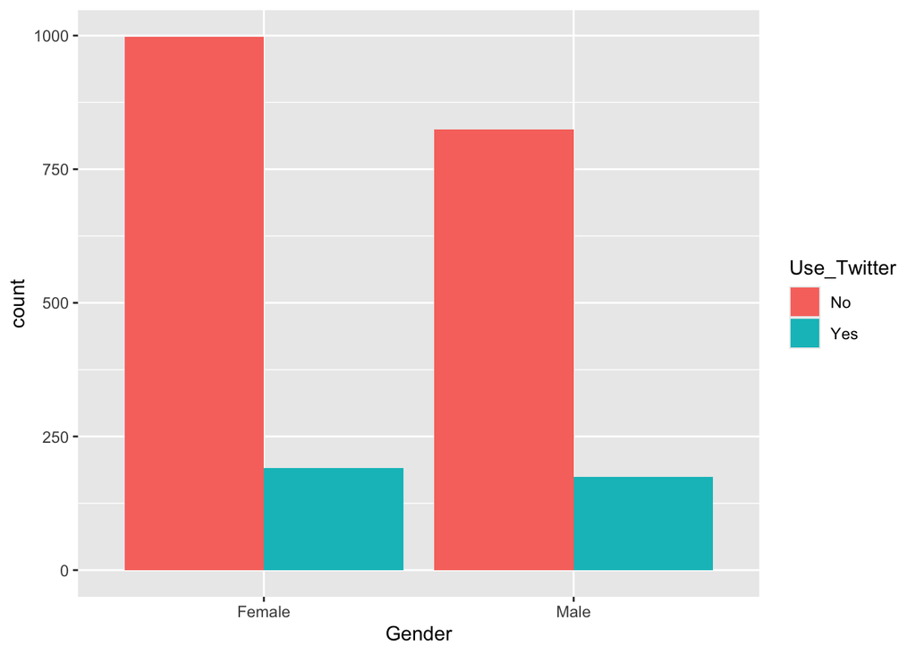

```r
my_df %>%
  ggplot (aes(x=Gender, fill = Use_Twitter)) + geom_bar (position = 'dodge')
```

A Pearson’s Chi-Square test of independence shows a significant positive relationship between Gender and Facebook use, χ²(1, N = 2189) = 18.05, p < 0.001.

On the other hand, a Pearson’s Chi-Square test shows no significant relationship between Gender and Twitter use, χ²(1, N = 2189) = 0.705, p = 0.401 (p>0.05). This could be because of the low proportion of Twitter users in the sample (17%).

### Twitter Use and Facebook Use

```r
chisq.test(
  x= my_df$Use_Facebook,
  y= my_df$Use_Twitter
)
```

```
##
##  Pearson's Chi-squared test with Yates' continuity correction
##
## data:  my_df$Use_Facebook and my_df$Use_Twitter
## X-squared = 175.13, df = 1, p-value < 0.00000000000000022
```

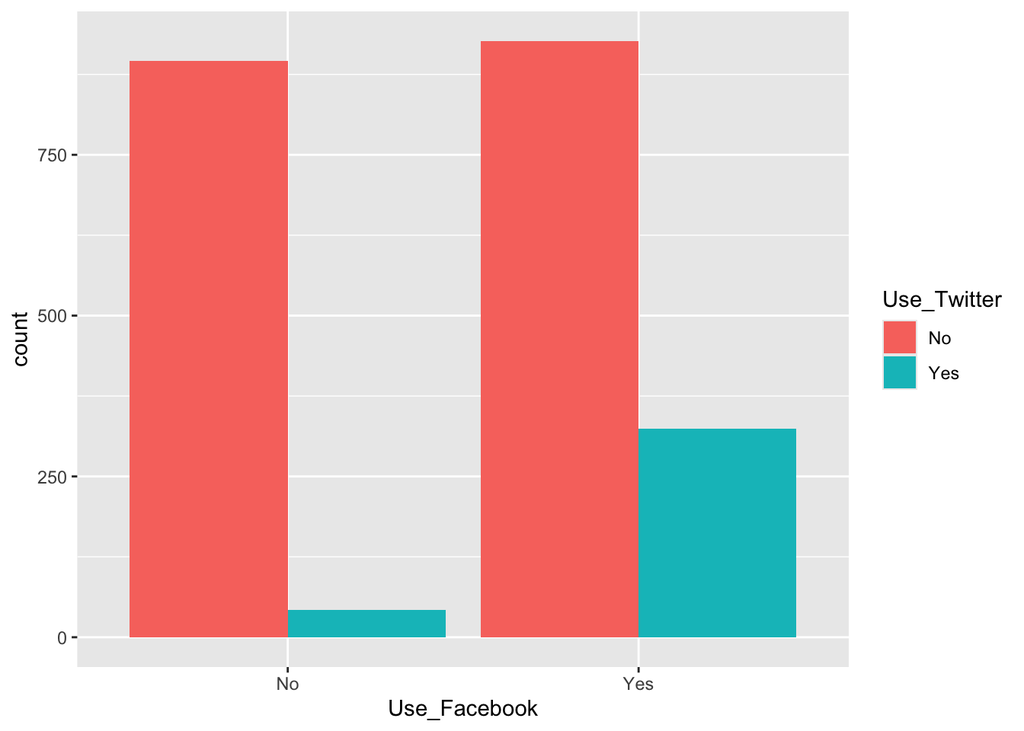

```r
my_df %>% ggplot(aes(x = Use_Facebook, fill = Use_Twitter)) + geom_bar (position = 'dodge')
```

A Pearson’s Chi-Square test of independence shows a significant positive relationship between Facebook use and Twitter use, χ²(1, N = 2189) = 175.13, p < 0.001.

We see that Gender and Twitter use both have significant relationships with Facebook use. The Twitter-Facebook relationship seems to be stronger than the Gender-Facebook relationship based on a higher X² value returned in the Chi-Square test.

These two relationships can be further explored with Fisher’s exact test for count data.

```r
fisher.test(
  x = my_df$Gender,
  y = my_df$Use_Facebook
)
```

```
##
##  Fisher's Exact Test for Count Data
##
## data:  my_df$Gender and my_df$Use_Facebook
## p-value = 0.00002122
## alternative hypothesis: true odds ratio is not equal to 1
## 95 percent confidence interval:
##  0.5790543 0.8201241
## sample estimates:
## odds ratio
##  0.6892201
```

```r
fisher.test(
  x = my_df$Use_Twitter,
  y = my_df$Use_Facebook
)
```

```
##
##  Fisher's Exact Test for Count Data
##
## data:  my_df$Use_Twitter and my_df$Use_Facebook
## p-value < 0.00000000000000022
## alternative hypothesis: true odds ratio is not equal to 1
## 95 percent confidence interval:
##   5.312226 10.675286
## sample estimates:
## odds ratio
##   7.449831
```

A Fisher’s exact test shows a significant negative relationship between Gender and Facebook use, OR = 0.69, 95% CI [0.58, 0.82], p < 0.001, suggesting that men are 31% less likely than women to use Facebook. The 95% confidence interval indicates that the true population odds ratio is likely between 0.58 and 0.82, meaning men’s Facebook use is at least 18% lower and at most 42% lower than that of women.

A Fisher’s exact test shows a significant positive relationship between Twitter use and Facebook use, OR = 7.45, 95% CI [5.31, 10.68], p < 0.001, suggesting that those who use Twitter are more than 7 times more likely to use Facebook compared to those who who do not use Twitter. The 95% confidence interval indicates that the true population odds ratio is likely between 5.31 and 10.68, meaning that Twitter users have at least 5.3 times higher odds and at most 10.7 times higher odds of using Facebook than non-Twitter users.

## Logistic Regression

```r
my_df <- my_df %>%
  mutate(
    Gender = factor(Gender),
    Use_Facebook = factor(Use_Facebook, levels = c("No", "Yes")),
    Use_Twitter = factor(Use_Twitter, levels = c("No", "Yes"))
  )

model <- glm(Use_Facebook ~ Gender + Use_Twitter, data = my_df, family = binomial)

summary(model)
```

```
##
## Call:
## glm(formula = Use_Facebook ~ Gender + Use_Twitter, family = binomial,
##     data = my_df)
##
## Coefficients:
##                Estimate Std. Error z value             Pr(>|z|)
## (Intercept)     0.22920    0.06263   3.660             0.000252 ***
## GenderMale     -0.43078    0.09101  -4.733           0.00000221 ***
## Use_TwitterYes  2.03769    0.17128  11.897 < 0.0000000000000002 ***
## ---
## Signif. codes:  0 '***' 0.001 '**' 0.01 '*' 0.05 '.' 0.1 ' ' 1
##
## (Dispersion parameter for binomial family taken to be 1)
##
##     Null deviance: 2989.7  on 2188  degrees of freedom
## Residual deviance: 2765.0  on 2186  degrees of freedom
## AIC: 2771
##
## Number of Fisher Scoring iterations: 4
```

```r
my_df$Predicted_Prob <- predict(model, type = "response")
head(my_df[, c("Gender", "Use_Twitter", "Predicted_Prob")])
```

```
## # A tibble: 6 × 3
##   Gender Use_Twitter Predicted_Prob
##   <fct>  <fct>                <dbl>
## 1 Female Yes                  0.906
## 2 Male   No                   0.450
## 3 Male   No                   0.450
## 4 Female No                   0.557
## 5 Female Yes                  0.906
## 6 Female No                   0.557
```

```r
new_data <- data.frame(
  Gender = factor(c("Male", "Male", "Female", "Female"), levels = c("Male", "Female")),
  Use_Twitter = factor(c("No", "Yes", "No", "Yes"), levels = c("No", "Yes"))
)

new_data$Predicted_Prob <- predict(model, newdata = new_data, type = "response")

new_data
```

```
##   Gender Use_Twitter Predicted_Prob
## 1   Male          No      0.4497752
## 2   Male         Yes      0.8624882
## 3 Female          No      0.5570495
## 4 Female         Yes      0.9060972
```

[figure not shown]

```r
ggplot(new_data, aes(x = interaction(Gender, Use_Twitter), y = Predicted_Prob, fill = Gender)) +
  geom_bar(stat = "identity", position = "dodge") +
  labs(x = "Gender & Twitter Use", y = "Predicted Probability of Facebook Use", title = "Predicted Probabilities of Facebook Use") +
  theme_minimal()
```

[figure not shown]

```r
ggplot(new_data, aes(x = interaction(Gender, Use_Twitter), y = Predicted_Prob, fill = Gender)) +
  geom_col(position = "dodge", width = 0.6) +
  geom_text(aes(label = round(Predicted_Prob, 2)), vjust = -0.5) +
  labs(x = "Gender & Twitter Use", y = "Predicted Probability of Facebook Use", title = "Predicted Probabilities of Facebook Use") +
  theme_minimal()
```

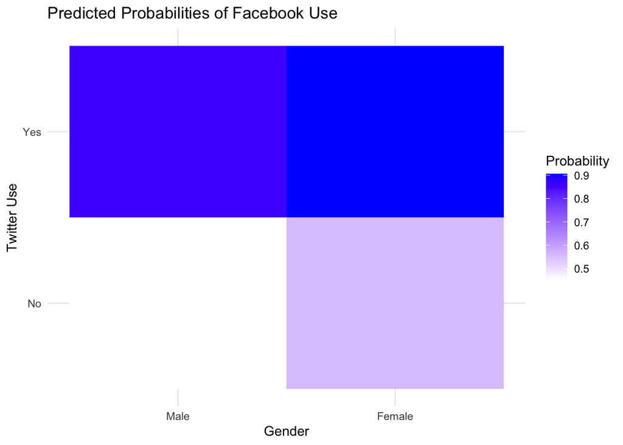

```r
ggplot(new_data, aes(x = Gender, y = Use_Twitter, fill = Predicted_Prob)) +
  geom_tile() +
  scale_fill_gradient(low = "white", high = "blue") +
  labs(x = "Gender", y = "Twitter Use", fill = "Probability", title = "Predicted Probabilities of Facebook Use") +
  theme_minimal()
```

```r
knitr::kable(exp(cbind(OR = coef(model), confint.default(model))))
```

|  | OR | 2.5 % | 97.5 % |
| --- | --- | --- | --- |
| (Intercept) | 1.2575888 | 1.1123257 | 1.4218223 |
| GenderMale | 0.6500051 | 0.5438143 | 0.7769317 |
| Use_TwitterYes | 7.6728676 | 5.4848374 | 10.7337543 |

## Summary of Findings

The likeliest person in our sample to be a Facebook user is a Twitter-using Female (90.6% predicted probability) and the least likely person to be a Facebook user is a non-Twitter-using Male (45% predicted probability).

Gender: Men were significantly less likely to use Facebook than women (β = -0.431, p < 0.001). The odds of Facebook use for men were 35% lower compared to women (OR = 0.65, 95% CI: 0.54 - 0.78). The predicted probability of Facebook use was ~55.7% for women and ~44.9% for men, holding Twitter usage constant.

Twitter Usage: Those who used Twitter were significantly more likely to use Facebook (β = 2.038, p < 0.001). Twitter users had 7.67 times higher odds of using Facebook compared to non-Twitter users (OR = 7.67, 95% CI: 5.48 - 10.73).

Twitter users are more likely to use Facebook even after controlling for Gender. Gender also has an independent effect on Facebook use.

## Predicting Gender from Social Media Use

```r
N <- 2189
z <- 1.96
both_count <- my_df %>% filter(Use_Twitter == "Yes" & Use_Facebook == "Yes") %>% nrow()
neither_count <- my_df %>% filter(Use_Twitter == "No" & Use_Facebook == "No") %>% nrow()

p_both <- both_count / N
p_neither <- neither_count / N

se <- function(p, N) sqrt((p * (1 - p)) / N)

se_both <- se(p_both, N)
se_neither <- se(p_neither, N)

ci_both <- c(p_both - z * se_both, p_both + z * se_both)
ci_neither <- c(p_neither - z * se_neither, p_neither + z * se_neither)

my_df$Gender_binary <- ifelse(my_df$Gender == "Female", 1, 0)

logit_model <- glm(Gender_binary ~ Use_Twitter + Use_Facebook, data = my_df, family = binomial)

summary(logit_model)
```

```
##
## Call:
## glm(formula = Gender_binary ~ Use_Twitter + Use_Facebook, family = binomial,
##     data = my_df)
##
## Coefficients:
##                 Estimate Std. Error z value   Pr(>|z|)
## (Intercept)     -0.02650    0.06555  -0.404     0.6860
## Use_TwitterYes  -0.26746    0.12038  -2.222     0.0263 *
## Use_FacebookYes  0.43078    0.09101   4.733 0.00000221 ***
## ---
## Signif. codes:  0 '***' 0.001 '**' 0.01 '*' 0.05 '.' 0.1 ' ' 1
##
## (Dispersion parameter for binomial family taken to be 1)
##
##     Null deviance: 3018.3  on 2188  degrees of freedom
## Residual deviance: 2994.9  on 2186  degrees of freedom
## AIC: 3000.9
##
## Number of Fisher Scoring iterations: 4
```

```r
exp(coef(logit_model))
```

```
##     (Intercept)  Use_TwitterYes Use_FacebookYes
##       0.9738490       0.7653183       1.5384495
```

```r
exp(confint(logit_model))
```

```
##                     2.5 %    97.5 %
## (Intercept)     0.8563564 1.1073593
## Use_TwitterYes  0.6043937 0.9691009
## Use_FacebookYes 1.2874673 1.8394952
```

```r
new_data <- data.frame(Use_Twitter = c("Yes", "Yes", "No", "No"), Use_Facebook = c("Yes", "No", "Yes", "No"))

new_data$predicted_female <- predict(logit_model, newdata = new_data, type = "response")

new_data
```

```
##   Use_Twitter Use_Facebook predicted_female
## 1         Yes          Yes        0.5341499
## 2         Yes           No        0.4270341
## 3          No          Yes        0.5997146
## 4          No           No        0.4933756
```

- Proportion using both Twitter and Facebook: 14.8% (95% CI: 13.3% - 16.3%).
- Proportion using neither platform: 40.9% (95% CI: 38.9% - 42.9%).